# EDA For DDS Project

Jonathon Roach

10/14/2019

## Introduction

```r
library(tidyverse)
library(class)
library(stringr)
library(forcats)
theme_set(theme_bw())

beers <- read.csv("http://raw.githubusercontent.com/BivinSadler/MDS-6306-Doing-Data-Science-Fall-2019/master/Unit%208%20and%209%20Case%20Study%201/Beers.csv")

breweries <- read.csv("https://raw.githubusercontent.com/BivinSadler/MDS-6306-Doing-Data-Science-Fall-2019/master/Unit%208%20and%209%20Case%20Study%201/Breweries.csv")
```

Seems like there are Breweries going by the same name in different cities. We may need to accout for this later. It’s going to be important for us to reference beweries by Brew_ID rather than name.

```r
duplicates <- breweries %>%
  group_by(Name) %>%
  summarise(count=n()) %>%
  arrange(desc(count)) %>%
  filter(count == 2) %>%
  select(Name)



breweries %>%
  filter(Name %in% duplicates$Name) %>%
  arrange(Name)
```

```
##    Brew_ID                    Name         City State
## 1       13      Blackrocks Brewery    Marquette    MI
## 2       96      Blackrocks Brewery    Marquette    MA
## 3      383   Blue Mountain Brewery        Afton    VA
## 4      415   Blue Mountain Brewery    Arrington    VA
## 5      378 Lucette Brewing Company    Menominee    WI
## 6      457 Lucette Brewing Company    Menominie    WI
## 7      167     Oskar Blues Brewery     Longmont    CO
## 8      504     Oskar Blues Brewery        Lyons    CO
## 9      262     Otter Creek Brewing    Waterbury    VT
## 10     276     Otter Creek Brewing   Middlebury    VT
## 11     164 Sly Fox Brewing Company Phoenixville    PA
## 12     372 Sly Fox Brewing Company    Pottstown    PA
## 13      59  Summit Brewing Company     St. Paul    MN
## 14     139  Summit Brewing Company      St Paul    MN
```

Which style of beer is most commonly brewed?

```r
head(
beers %>%
  group_by(Style) %>%
  summarise(count = n()) %>%
  arrange(desc(count))
)
```

```
## # A tibble: 6 x 2
##   Style                          count
##   <fct>                          <int>
## 1 American IPA                     424
## 2 American Pale Ale (APA)          245
## 3 American Amber / Red Ale         133
## 4 American Blonde Ale              108
## 5 American Double / Imperial IPA   105
## 6 American Pale Wheat Ale           97
```

Joining data. Answer to question #2.

```r
dat <- left_join(beers, breweries, by=c("Brewery_id" = "Brew_ID")) %>%
       rename(Beer = Name.x, Brewery = Name.y)

head(dat)
```

```
##                  Beer Beer_ID   ABV IBU Brewery_id
## 1            Pub Beer    1436 0.050  NA        409
## 2         Devil's Cup    2265 0.066  NA        178
## 3 Rise of the Phoenix    2264 0.071  NA        178
## 4            Sinister    2263 0.090  NA        178
## 5       Sex and Candy    2262 0.075  NA        178
## 6        Black Exodus    2261 0.077  NA        178
##                            Style Ounces                   Brewery City
## 1            American Pale Lager     12 10 Barrel Brewing Company Bend
## 2        American Pale Ale (APA)     12       18th Street Brewery Gary
## 3                   American IPA     12       18th Street Brewery Gary
## 4 American Double / Imperial IPA     12       18th Street Brewery Gary
## 5                   American IPA     12       18th Street Brewery Gary
## 6                  Oatmeal Stout     12       18th Street Brewery Gary
##   State
## 1    OR
## 2    IN
## 3    IN
## 4    IN
## 5    IN
## 6    IN
```

Which state has the most breweries? Answer to question #1.

```r
head(
breweries %>%
  group_by(State) %>%
  summarize(count=n()) %>%
  arrange(desc(count))
)
```

```
## # A tibble: 6 x 2
##   State count
##   <fct> <int>
## 1 " CO"    47
## 2 " CA"    39
## 3 " MI"    32
## 4 " OR"    29
## 5 " TX"    28
## 6 " PA"    25
```

Which brewery produces the most individual beer types?

```r
head(
dat %>%
  group_by(Brewery) %>%
  summarise(count = n()) %>%
  arrange(desc(count))
)
```

```
## # A tibble: 6 x 2
##   Brewery                    count
##   <fct>                      <int>
## 1 Brewery Vivant                62
## 2 Oskar Blues Brewery           46
## 3 Sun King Brewing Company      38
## 4 Cigar City Brewing Company    25
## 5 Sixpoint Craft Ales           24
## 6 Hopworks Urban Brewery        23
```

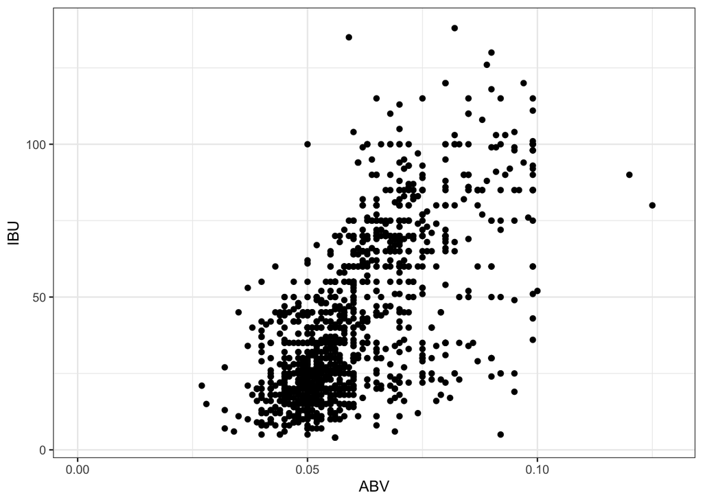

```r
dat %>%
  ggplot(aes(x=ABV, y=IBU)) +
    geom_point()
```

Let’s identify the IPA’s

```r
dat$is_IPA <- str_detect(dat$Style, "IPA")

head(dat %>% filter(is_IPA == TRUE) %>% select(Beer, is_IPA, Style))
```

```
##                        Beer is_IPA                          Style
## 1       Rise of the Phoenix   TRUE                   American IPA
## 2                  Sinister   TRUE American Double / Imperial IPA
## 3             Sex and Candy   TRUE                   American IPA
## 4              Cone Crusher   TRUE American Double / Imperial IPA
## 5           Troll Destroyer   TRUE                    Belgian IPA
## 6 21st Amendment IPA (2006)   TRUE                   American IPA
```

We can see below that our REGEX isn’t picking up anything that it shouldn’t.

```r
unique(dat[str_detect(dat$Style, "IPA"),]$Style)
```

```
## [1] American IPA                   American Double / Imperial IPA
## [3] Belgian IPA                    English India Pale Ale (IPA)
## [5] American White IPA
## 100 Levels:  Abbey Single Ale Altbier ... Witbier
```

Now let’s identify the ales (including IPA’s). We need to be careful. Just looking for the string, “ale” is not a precise solution. For example, “Yard S[ale] Winter Lager” is not an ale, and we don’t want it to get picked up in our results.

```r
dat$is_ale <- str_detect(dat$Beer, "ale")


head(dat %>% filter(is_ale == TRUE) %>% select(Beer, is_ale, Style) )
```

```
##                           Beer is_ale                   Style
## 1      British Pale Ale (2010)   TRUE        English Pale Ale
## 2             British Pale Ale   TRUE        English Pale Ale
## 3           Klickitat Pale Ale   TRUE American Pale Ale (APA)
## 4         Dusty Trail Pale Ale   TRUE American Pale Ale (APA)
## 5          Keebarlin' Pale Ale   TRUE American Pale Ale (APA)
## 6 Poleeko Gold Pale Ale (2009)   TRUE American Pale Ale (APA)
```

We will also need to be careful using REGEX on the Style column, as simply searching for the “ale” string doesn’t guarantee that we’re selecting ales either (see for example: “Euro P[ale] Lager”)

```r
unique(dat[str_detect(dat$Style, "ale"),]$Style)
```

```
##  [1] American Pale Lager          American Pale Ale (APA)
##  [3] American Pale Wheat Ale      English Pale Ale
##  [5] Belgian Pale Ale             English India Pale Ale (IPA)
##  [7] Euro Pale Lager              Belgian Strong Pale Ale
##  [9] English Pale Mild Ale        American India Pale Lager
## 100 Levels:  Abbey Single Ale Altbier ... Witbier
```

Looks like searching for “Ale” is the more sensible decision.

```r
unique(dat[str_detect(dat$Style, "Ale"),]$Style)
```

```
##  [1] American Pale Ale (APA)      Saison / Farmhouse Ale
##  [3] English Strong Ale           American Black Ale
##  [5] Belgian Dark Ale             American Blonde Ale
##  [7] American Amber / Red Ale     American Brown Ale
##  [9] American Pale Wheat Ale      Belgian Strong Dark Ale
## [11] English Pale Ale             Pumpkin Ale
## [13] Belgian Pale Ale             American Wild Ale
## [15] English Brown Ale            Cream Ale
## [17] English India Pale Ale (IPA) American Strong Ale
## [19] Scotch Ale / Wee Heavy       English Dark Mild Ale
## [21] Irish Red Ale                Belgian Strong Pale Ale
## [23] English Pale Mild Ale        Scottish Ale
## [25] Abbey Single Ale             American Dark Wheat Ale
## [27] Old Ale                      Flanders Red Ale
## [29] Wheat Ale
## 100 Levels:  Abbey Single Ale Altbier ... Witbier
```

```r
dat$is_ale <- str_detect(dat$Beer, "Ale")


head(dat %>% filter(is_ale == TRUE) %>% select(Beer, is_ale, Style) )
```

```
##                      Beer is_ale                   Style
## 1 British Pale Ale (2010)   TRUE        English Pale Ale
## 2        British Pale Ale   TRUE        English Pale Ale
## 3      Klickitat Pale Ale   TRUE American Pale Ale (APA)
## 4    Dusty Trail Pale Ale   TRUE American Pale Ale (APA)
## 5             Liberty Ale   TRUE            American IPA
## 6     Keebarlin' Pale Ale   TRUE American Pale Ale (APA)
```

```r
ales <- dat %>% filter(is_ale == TRUE) %>% select(Beer, is_ale, Style)

head(
ales %>%
  group_by(Style) %>%
  summarise(count = n()) %>%
  arrange(desc(count))
)
```

```
## # A tibble: 6 x 2
##   Style                    count
##   <fct>                    <int>
## 1 American Pale Ale (APA)    184
## 2 American Amber / Red Ale    78
## 3 American Blonde Ale         54
## 4 American IPA                44
## 5 American Brown Ale          43
## 6 American Pale Wheat Ale     23
```

Hmm…Why are there beers like “Witbier” included? Seems like there are certain styles that masquerade as ales (perhaps for maketing purposes?)

```r
ales %>%
  filter(Style == "Witbier")
```

```
##                                  Beer is_ale   Style
## 1                    White Zombie Ale   TRUE Witbier
## 2                    White Zombie Ale   TRUE Witbier
## 3          Quick Wit Belgianesque Ale   TRUE Witbier
## 4                  Snowshoe White Ale   TRUE Witbier
## 5                       SNO White Ale   TRUE Witbier
## 6         Full Moon Belgian White Ale   TRUE Witbier
## 7  Full Moon Belgian White Ale (2007)   TRUE Witbier
## 8                           White Ale   TRUE Witbier
## 9               River North White Ale   TRUE Witbier
## 10             Saint Archer White Ale   TRUE Witbier
## 11   Sockeye Belgian Style Summer Ale   TRUE Witbier
## 12                 Triangle White Ale   TRUE Witbier
## 13                   Upland Wheat Ale   TRUE Witbier
```

Let’s see which beers disguise themselves as ales most often?

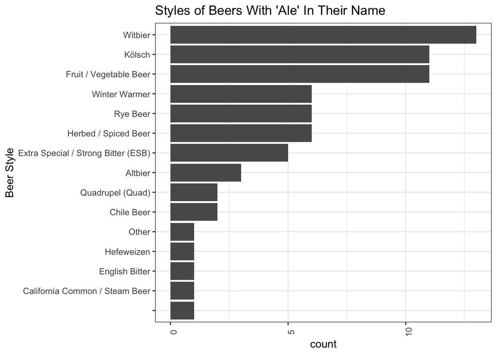

```r
ales %>%
  filter(!str_detect(Style, "Ale") & !str_detect(Style, "IPA")) %>%
  group_by(Style) %>%
  summarise(count=n()) %>%
  ungroup() %>%
  ggplot(aes(reorder(Style,count), count)) +
    theme(axis.text.x = element_text(angle = 90)) +
    geom_bar(stat = "identity") +
    coord_flip() +
    labs(x="Beer Style",
         title = "Styles of Beers With 'Ale' In Their Name")
```

Ok, so after some googling, I found that any one of these beers can be considered an ale. The ale vs. lager distinction is determined by the kind of yeast that is used to make the beer. Cool. We’ll use REGEX on the beer name rather than the style to get what we need. Good to know.

Now let’s make an indicator that distinguishes IPAs from regular ales and other beer styles.

```r
dat$beer_type <- if_else(dat$is_IPA == TRUE & dat$is_ale == TRUE, "IPA",
                         if_else(dat$is_IPA == FALSE & dat$is_ale == TRUE, "Ale",
                                 if_else(dat$is_IPA == TRUE & dat$is_ale == FALSE, "IPA", "Other")))
```

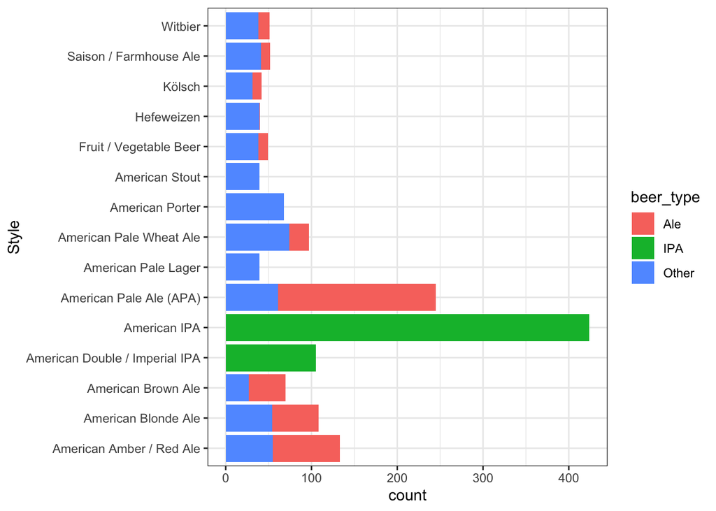

```r
top_15_styles <- dat %>%
  group_by(Style) %>%
  summarise(count=n()) %>%
  arrange(desc(count)) %>%
  head(15) %>%
  select(Style)

dat %>%
  filter(dat$Style %in% top_15_styles$Style) %>%
  ggplot(aes(Style, fill=beer_type)) +
    geom_bar(stat = "count") +
    coord_flip()
```

Looks like we need to use REGEX on both the beer name and the Style. Clearly something like “American Pale Wheat Ale” is never going to be a lager. We’ll do the same thing with IPA’s just to be safe.

```r
dat$is_ale <- str_detect(dat$Beer, "Ale") | str_detect(dat$Style, "Ale")

dat$is_IPA <- str_detect(dat$Beer, "IPA") | str_detect(dat$Style, "IPA")

dat$beer_type <- if_else(dat$is_IPA == TRUE & dat$is_ale == TRUE, "IPA",
                         if_else(dat$is_IPA == FALSE & dat$is_ale == TRUE, "Ale",
                                 if_else(dat$is_IPA == TRUE & dat$is_ale == FALSE, "IPA", "Other")))
```

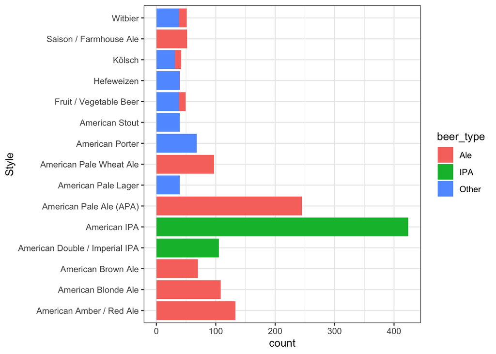

```r
p <- dat %>%
  filter(dat$Style %in% top_15_styles$Style) %>%
  ggplot(aes(Style, fill=beer_type)) +
    geom_bar(stat = "count") +
    coord_flip()

p
```

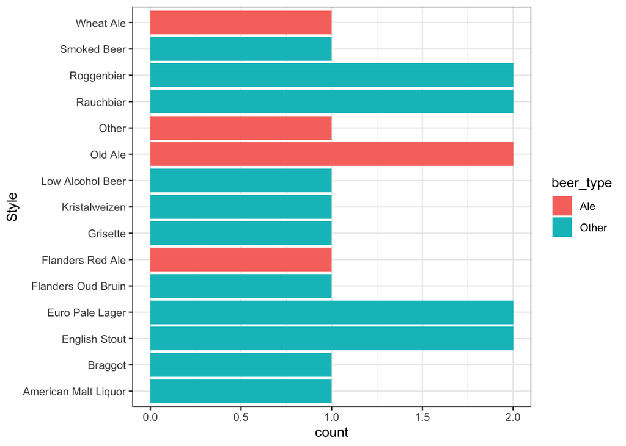

```r
bottom_15_styles <- dat %>%
  group_by(Style) %>%
  summarise(count=n()) %>%
  arrange(desc(count)) %>%
  tail(15) %>%
  select(Style)

p %+% (dat %>% filter(dat$Style %in% bottom_15_styles$Style))
```

Ok, I think our classifications of “ale”, “IPA”, and “other” are accurate. Let’s do some modeling.

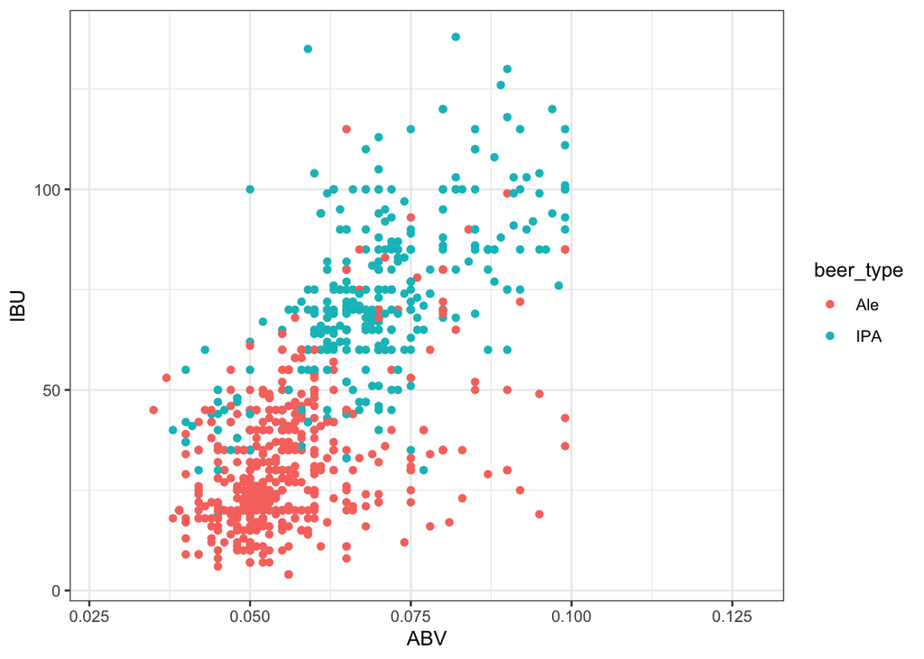

```r
dat %>%
  filter(beer_type != "Other") %>%
  ggplot(aes(x=ABV, y=IBU, color = beer_type)) +
    geom_point()
```

Investigating True Relationship Between ABV and IBU

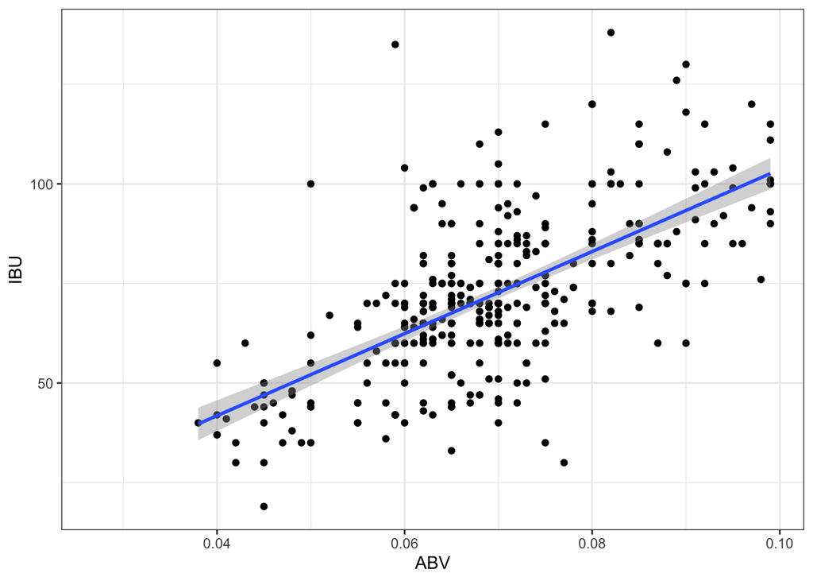

```r
dat %>%
  filter(!beer_type %in% c("Other", "Ale")) %>%
  ggplot(aes(x=ABV, y=IBU)) +
    geom_point() +
    geom_smooth(method = "lm")
```

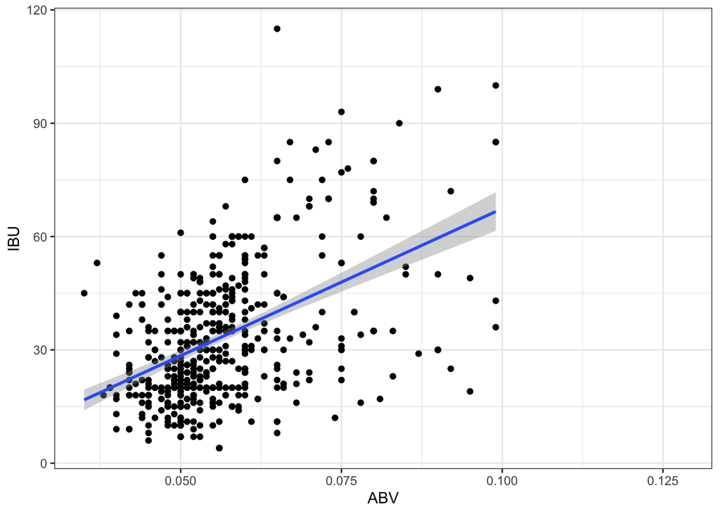

```r
dat %>%
  filter(!beer_type %in% c("Other", "IPA")) %>%
  ggplot(aes(x=ABV, y=IBU)) +
    geom_point() +
    geom_smooth(method = "lm")
```

Train/test split data

```r
dat_mod <- (dat %>% filter(beer_type != "Other"))

train_inds <- sample(nrow(dat_mod), floor(0.7*nrow(dat_mod)))

train <- dat_mod[train_inds,]

test <- dat_mod[-train_inds,]

train <- train[!is.na(train$IBU) & !is.na(train$ABV),]

test <- train[!is.na(test$IBU) & !is.na(test$ABV),]

head(train)
```

```
##                                Beer Beer_ID   ABV IBU Brewery_id
## 1577   Hop Slayer Double IPA (2011)     430 0.082 100        362
## 384         Terrace Hill Double IPA    1647 0.095  99        351
## 116               Field 41 Pale Ale     965 0.044  38        484
## 1188                  RoughTail IPA    1576 0.070  80        377
## 967                      Ranger IPA    2230 0.065  70         83
## 1339 Northern Lights India Pale Ale     368 0.065  52        384
##                               Style Ounces                       Brewery
## 1577 American Double / Imperial IPA     12    Wild Onion Brewing Company
## 384  American Double / Imperial IPA     16 Central Coast Brewing Company
## 116         American Pale Ale (APA)     12  Bale Breaker Brewing Company
## 1188                   American IPA     16     RoughTail Brewing Company
## 967                    American IPA     12   New Belgium Brewing Company
## 1339                   American IPA     12            Starr Hill Brewery
##                 City State is_IPA is_ale beer_type
## 1577 Lake Barrington    IL   TRUE  FALSE       IPA
## 384  San Luis Obispo    CA   TRUE  FALSE       IPA
## 116           Yakima    WA  FALSE   TRUE       Ale
## 1188    Midwest City    OK   TRUE  FALSE       IPA
## 967     Fort Collins    CO   TRUE  FALSE       IPA
## 1339          Crozet    VA   TRUE   TRUE       IPA
```

```r
head(test)
```

```
##                                Beer Beer_ID   ABV IBU Brewery_id
## 116               Field 41 Pale Ale     965 0.044  38        484
## 1188                  RoughTail IPA    1576 0.070  80        377
## 967                      Ranger IPA    2230 0.065  70         83
## 1339 Northern Lights India Pale Ale     368 0.065  52        384
## 1061                       Old Chub       5 0.080  35        167
## 1601                      Belgorado     928 0.067  45        425
##                        Style Ounces                      Brewery
## 116  American Pale Ale (APA)     12 Bale Breaker Brewing Company
## 1188            American IPA     16    RoughTail Brewing Company
## 967             American IPA     12  New Belgium Brewing Company
## 1339            American IPA     12           Starr Hill Brewery
## 1061            Scottish Ale     12          Oskar Blues Brewery
## 1601             Belgian IPA     12      Wynkoop Brewing Company
##              City State is_IPA is_ale beer_type
## 116        Yakima    WA  FALSE   TRUE       Ale
## 1188 Midwest City    OK   TRUE  FALSE       IPA
## 967  Fort Collins    CO   TRUE  FALSE       IPA
## 1339       Crozet    VA   TRUE   TRUE       IPA
## 1061     Longmont    CO  FALSE   TRUE       Ale
## 1601       Denver    CO   TRUE  FALSE       IPA
```

```r
preds <- knn(train = train[,3:4], test = test[,3:4], cl = train$beer_type, k = 3)

table(actual=test$beer_type, predicted=preds)
```

```
##       predicted
## actual Ale IPA
##    Ale 233  19
##    IPA  25 143
```

Wow, k=3 was a pretty good guess. Our model predicts with 90% accuracy. Let’s run a simulation to see which k value is optimal (note that the following code is extremely slow. You will have to give it 5-10 minutes to run)

```r
sims <- 1000L

iter <- 50L

accs <- vector(mode = "numeric", length = iter)

best_k <- vector(mode = "numeric", length = sims)


for (j in seq_len(sims)) {

  train_inds_sim <- sample(nrow(dat_mod), floor(0.7*nrow(dat_mod)))

  train_sim <- dat_mod[train_inds_sim,]

  test_sim <- dat_mod[-train_inds_sim,]

  train_sim <- train_sim[!is.na(train_sim$IBU) & !is.na(train_sim$ABV),]

  test_sim <- test_sim[!is.na(test_sim$IBU) & !is.na(test_sim$ABV),]


  for (i in seq_len(iter)) {

  pred_temp <- knn(train = train_sim[,3:4], test = test_sim[,3:4], cl = train_sim$beer_type, k = i)

  accs[[i]] <- sum(if_else(test_sim$beer_type == pred_temp,1,0)) / length(pred_temp)
  }

  best_k[[j]] <- which.max(accs)

}

best_k <- as.data.frame(best_k)

best_k %>%
  group_by(best_k) %>%
  summarise(count = n()) %>%
    arrange(desc(count))
```

```
## # A tibble: 44 x 2
##    best_k count
##     <dbl> <int>
##  1      5   259
##  2      6   119
##  3      4   106
##  4      3   105
##  5      1    98
##  6      7    67
##  7      8    36
##  8      2    18
##  9      9    17
## 10     12    12
## # … with 34 more rows
```

```r
preds <- knn(train = train[,3:4], test = test[,3:4], cl = train$beer_type, k = 5)

table(actual=test$beer_type, predicted=preds)
```

```
##       predicted
## actual Ale IPA
##    Ale 229  23
##    IPA  28 140
```

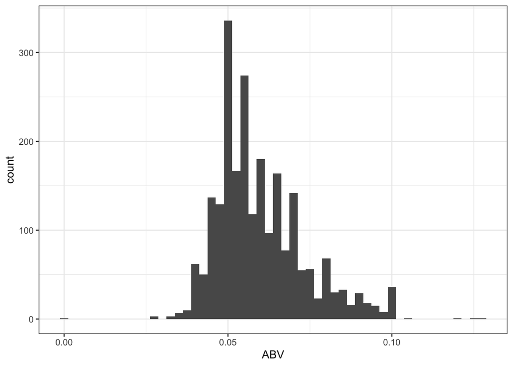

```r
dat %>%
  ggplot(aes(ABV)) +
    geom_histogram(binwidth = 0.0025)
```

Addressing missing values in each column. Answer to question #3.

```r
lapply(dat, function(x)mean(is.na(x)))
```

```
## $Beer
## [1] 0
##
## $Beer_ID
## [1] 0
##
## $ABV
## [1] 0.02572614
##
## $IBU
## [1] 0.4170124
##
## $Brewery_id
## [1] 0
##
## $Style
## [1] 0
##
## $Ounces
## [1] 0
##
## $Brewery
## [1] 0
##
## $City
## [1] 0
##
## $State
## [1] 0
##
## $is_IPA
## [1] 0
##
## $is_ale
## [1] 0
##
## $beer_type
## [1] 0
```

Question 4: Compute median ABV and IBU for each state and plot.

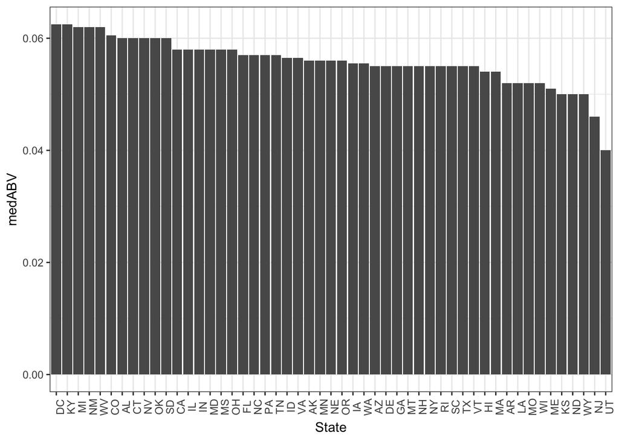

```r
dat %>%
  mutate(State = fct_reorder(State, ABV, .fun = median, na.rm = TRUE, .desc = TRUE)) %>%
  group_by(State) %>%
  summarise(medABV = median(ABV, na.rm = TRUE)) %>%
  ungroup() %>%
  ggplot(aes(State, medABV)) +
  theme(axis.text.x = element_text(angle = 90)) +
  geom_bar(stat = "identity")
```

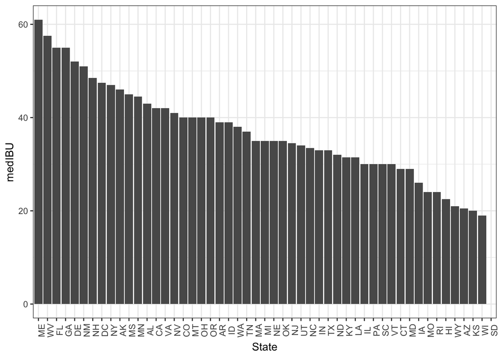

```r
dat %>%
  mutate(State = fct_reorder(State, IBU, .fun = median, na.rm = TRUE, .desc = TRUE)) %>%
  group_by(State) %>%
  summarise(medIBU = median(IBU, na.rm = TRUE)) %>%
  ungroup() %>%
  ggplot(aes(State, medIBU)) +
  theme(axis.text.x = element_text(angle = 90)) +
  geom_bar(stat = "identity")
```

Which state has the maximum ABV beer? Answer to question #5.

```r
dat %>%
  arrange(desc(ABV)) %>%
  select(State, ABV, Beer)
```

```
##      State   ABV                                                 Beer
## 1       CO 0.128 Lee Hill Series Vol. 5 - Belgian Style Quadrupel Ale
## 2       KY 0.125                                       London Balling
## 3       IN 0.120                                                 Csar
## 4       CO 0.104     Lee Hill Series Vol. 4 - Manhattan Style Rye Ale
## 5       NY 0.100                                               4Beans
## 6       CA 0.099                                        Lower De Boom
## 7       MN 0.099                      Forest Fire Imperial Smoked Rye
## 8       MI 0.099                                 Wizard Burial Ground
## 9       MI 0.099                     Hubris Quadrupel Anniversary Ale
## 10      MI 0.099           Vivant Belgian Style Imperial Stout (2012)
## 11      NV 0.099                           Very Noddy Lager (Current)
## 12      IN 0.099                                     Hopkick Dropkick
## 13      MA 0.099                               Imperial Pumpkin Stout
## 14      NJ 0.099                                              Epitome
```

[output cut: 2396 more lines]

Which state has the most bitter beer? Answer to question #5.

```r
dat %>%
  arrange(desc(IBU)) %>%
  select(State, IBU, Beer)
```

```
##      State IBU                                                 Beer
## 1       OR 138                            Bitter Bitch Imperial IPA
## 2       VA 135                                   Troopers Alley IPA
## 3       MA 130                                        Dead-Eye DIPA
## 4       OH 126                      Bay of Bengal Double IPA (2014)
## 5       MN 120                                         Abrasive Ale
## 6       VT 120                                         Heady Topper
## 7       VT 120                                         Heady Topper
## 8       TX 118                                         More Cowbell
## 9       MI 115                                           Hop A-Peel
## 10      IN 115                                     Hopkick Dropkick
## 11      DC 115                           On the Wings of Armageddon
## 12      CA 115                                        Blazing World
## 13      IN 115                                Overlord Imperial IPA
## 14      PA 113                                              113 IPA
```

[output cut: 2396 more lines]